# Looking at Internet Access in Albuquerque, New Mexico

## Hollis Wang

## 05/16/2021

## Overview

#### Understanding who doesn't have internet access, and where internet "deserts" are is an important part of discussing issues of internet accessibility. So I took a look at just this, and analyzed and mapped out where households that had no internet access in the Albuquerque Metropolitan Statistical Area (includes following counties: Bernalillo, Sandoval, Torrance, and Valencia).

#### This analysis uses two tools. The data pipeline and cleaning is done with python. I was able to build a Python package that takes two sets of census data -- internet subscription (S2801) and income data (S1901) -- to estimate households that have no internet access on a county tract level. And end result here is a CSV file that feeds into QGIS in order to map and visualize the data.

#### The analysis in the presentation looks only at one metric. But with the same QGIS file multiple metrics and views can be produced by changing the symbology.

##### - household population

##### - broadband access (household numbers, percentage of households, % better or worse than national average)

##### - no internet access (household numbers, percentage of households, % better or worse than national average)

##### - households that have only dial-up access (households numbers, percentage of households, % better or worse than national average)

## Python Package - abq_analyze

#### abq_analyze has a few functionalities:

#### - cleans census datasets for internet subscription and income for Albuquerque counties

#### - analyzes census data and outputs extract to fit it for GIS

#### - a web-scrapper that scrapes library locations in Albuquerque

##### *full code and all materials used for project can be found here https://github.com/hyw215/underline_interview_hyw.git

## Research & Assumptions

#### Additionally, numerous research papers have looked at American's willingness to pay for internet access. These papers have pointed to income as one of the most determinative factors for American's willingness.

#### The connection between income and internet access underpins the critical assumption that was made in order to estimate county-level internet data down to the tract level (internet subscription data is not available on the tract level)

#### Looking at libraries is also important to this analysis because libraries are a great source for internet access. Close proximity to a library can compensate for community's lack of household internet access. To put a number to its importance, one research paper estimated that 77 million people use libraries for internet access.

##### *references research is shown below

#### Ressearch Paper (Income connection with internet)

#### https://www.sciencedirect.com/science/article/abs/pii/S0308596105000510

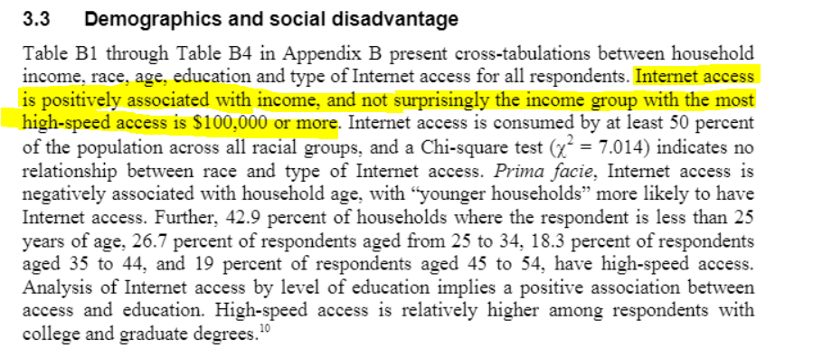

#### Ressearch Paper (Library research)

#### https://files.eric.ed.gov/fulltext/ED510740.pdf

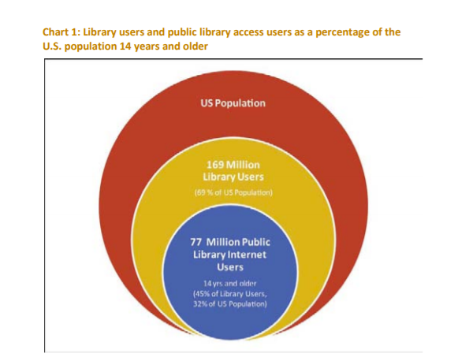

#### Ressearch Paper (Pew Research)

#### https://www.pewresearch.org/internet/2015/06/26/americans-internet-access-2000-2015/

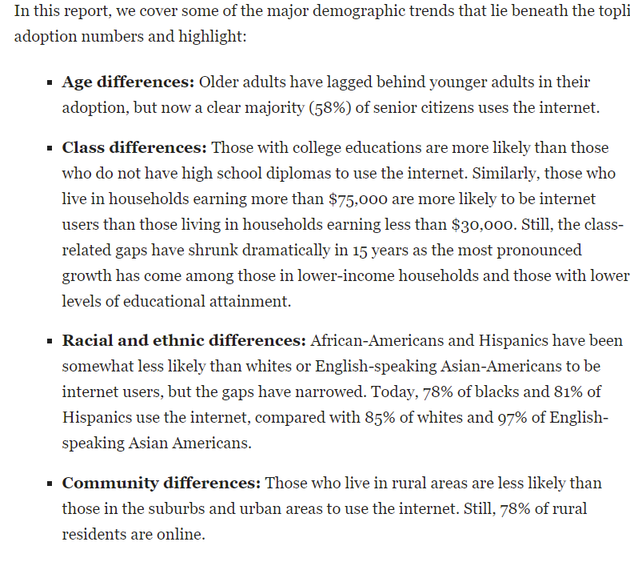

## Methodology

#### The core of this analysis involved getting around the problem that census internet subscription data is not available on a tract level of detail. The most granular level of detail is on the county level, and that isn't sufficient for this analysis. There is, however, income data on a census tract level and internet subscription data does breakdown some of its data by income.

#### I used income to link the data sources together. I'm applying the county-level internet rates to each tract in that county, and adjusting it by it's income.

### Analysis

#### Map of Albuquerque Metropolitan Statistical Area indicating where internet access is worse than national average

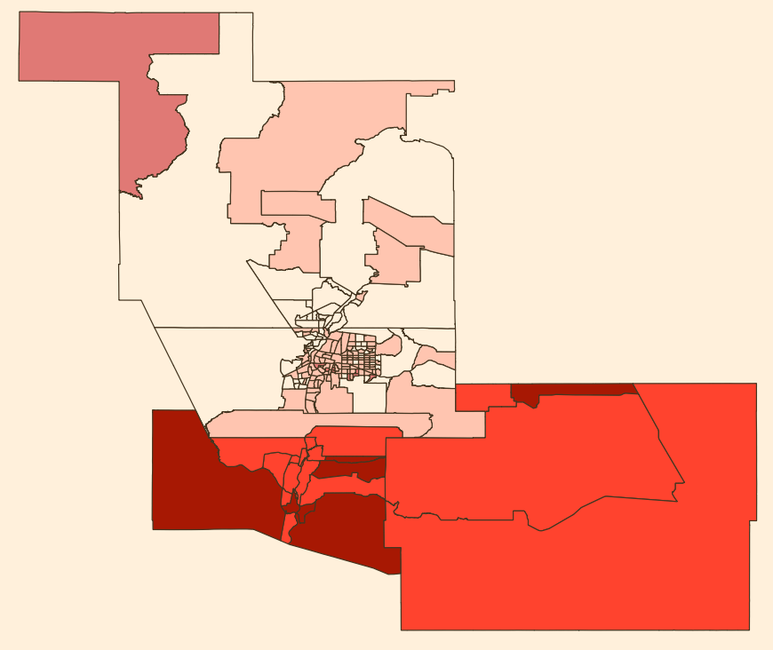

#### How to read the map: no color indicates the county tract is better than the national average; from lightest red to darkest is worse than national average by 0-25%, 25%-50%, 50%-75%, and more than 75%

### Analysis

#### Looking at the map, you can see that Albuquerque has room to grow in terms of internet adoption. Compared to the national average, there are more areas where a higher number of households have no internet access.

#### In many parts of Bernalillo County, the most populus county, the percentage of households with no internet access is up to 25% worse than the US national average.

#### Two counties in particular, Valencia and Torrence County, have poor rates of internet access. Some areas have percentages that are 84% worse than the national average. These areas are characteristically more rural and sparsely populated than other counties.

### Analysis - Bernalillo County

#### Taking a closer look at Bernalillo County, there are a some areas where internet access is worse than then national average by 25% to 50%. But the city does seem to be working on this, as evidenced by the concentration of library locations and other free wi-fi spots.

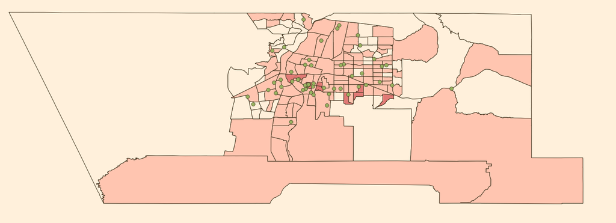